# PSCI 2300 Practice Midterm 2

YOUR VUNETID HERE:

2026-10-27

# PRACTICE MIDTERM 2: PSCI 2300

The actual exam is closed book and closed notes, paper and pencil. It will be shorter than this, but it will have similar types of questions.

Midterm 2 is more conceptual than Midterm 1. You will still need to read code and output, but most of the points come from thinking: What is the comparison? What must be true for it to tell us what we want to know? What does this number actually mean?

# Part 1: Interpreting Regression Results

### Question 1

Using the 67 Florida counties, we can ask how Bill Clinton’s 1996 vote is related to Al Gore’s 2000 vote. Both variables are the Democrat’s share of the two-party vote in the county, in percentage points (for example, `Gore00Share` = 100 × Gore / (Gore + Bush)). Each point is a Florida county. The solid line is the regression line. The dashed line is the 45-degree line (`geom_abline()`).

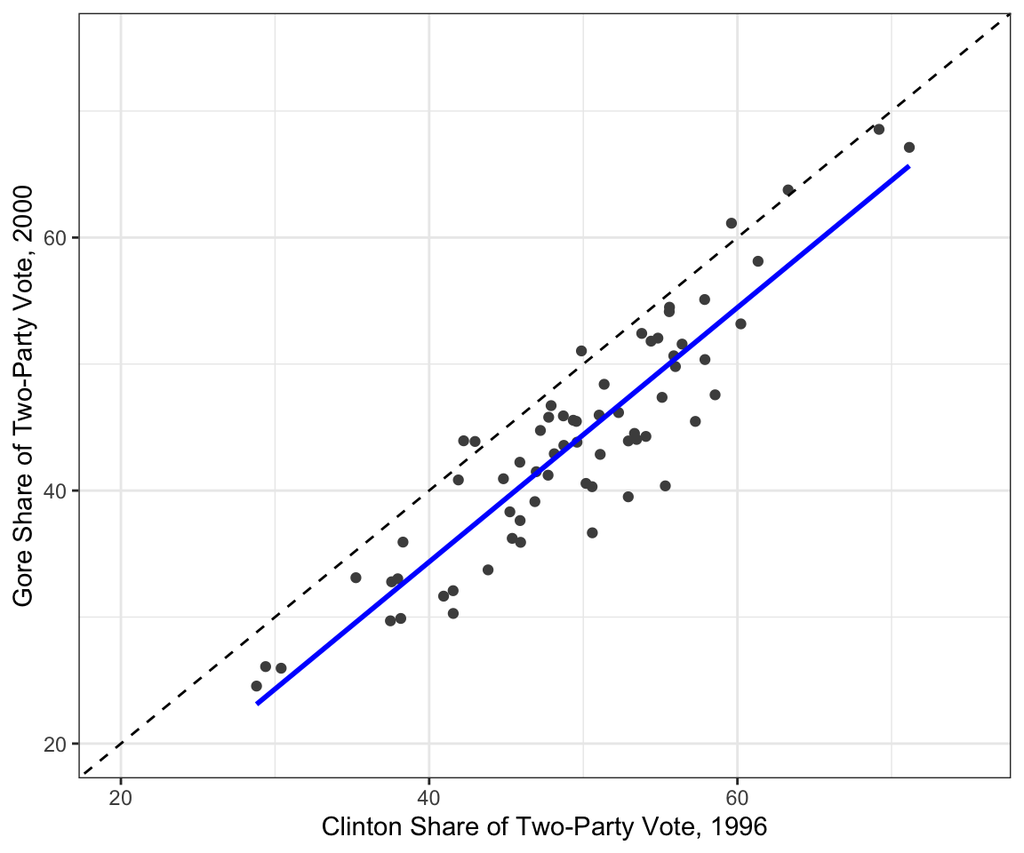

1. Describe the relationship: direction, strength, and any unusual points.
2. What does it mean for a county to fall exactly on the dashed line? Above it? Below it?
3. 62 of the 67 counties are below the dashed line. What does that tell you about Gore compared with Clinton? How is that related to the intercept of the regression in Question 2?
4. Why is the regression line not the same as the dashed line? If every county had given Gore exactly the same share as Clinton, what would the intercept and slope be?
5. Write the code that would produce this plot (you do not need to match the labels or colors).

### Question 2

Here is the regression of Gore’s 2000 vote share on Clinton’s 1996 vote share in the 67 Florida counties from Question 1.

```
Call:
lm(formula = Gore00Share ~ Clinton96Share, data = florida)

Coefficients:
   (Intercept)  Clinton96Share
        -5.839           1.005
```

1. What is the dependent variable? What is the independent variable? What is the unit of analysis?
2. Interpret the slope in words a reporter would understand.
3. Interpret the intercept. Does it mean anything here? (Clinton’s 1996 share in these counties ranged from 29% to 71%.)
4. What is Gore’s predicted vote share in a county where Clinton won 50% in 1996? Show the calculation, but you do not need to actually do it.

# Part 2: Visualizing Relationships

### Question 3

Which is the best way to visualize the distribution of a *continuous* variable, such as the age of survey respondents?

A. Scatterplot, with age on the x-axis and age on the y-axis.

B. Histogram, with age (grouped into bins) on the x-axis and the number of respondents in each bin on the y-axis.

C. Bar chart, with each unique age on the x-axis and the average age on the y-axis.

D. Line plot, with respondent number on the x-axis and age on the y-axis.

### Question 4

Which is the best way to visualize the distribution of a *discrete* variable, such as reported 2024 presidential vote (Harris or Trump)?

A. Bar chart, with each candidate on the x-axis and the number of respondents who chose that candidate on the y-axis.

B. Histogram, with vote choice grouped into bins on the x-axis and the density on the y-axis.

C. Boxplot, with vote choice on the y-axis.

D. Scatterplot, with each respondent on the x-axis and vote choice on the y-axis.

### Question 5

Which is the best way to visualize the relationship between two *continuous* variables, such as Clinton’s 1996 vote share and Gore’s 2000 vote share in Florida counties?

A. Bar chart, with Clinton’s share on the x-axis and the number of counties on the y-axis, filled by Gore’s share.

B. Boxplot, with Clinton’s share on the x-axis and Gore’s share on the y-axis.

C. Scatterplot, with one point per county, Clinton’s share on the x-axis and Gore’s share on the y-axis.

D. Two histograms, one for Clinton’s share and one for Gore’s share.

### Question 6

Which is the best way to visualize the relationship between two *discrete* variables, such as gender (Man or Woman) and reported 2024 presidential vote (Harris or Trump)?

A. Scatterplot, with gender on the x-axis and vote choice on the y-axis.

B. Line plot, with gender on the x-axis and the number of Trump voters on the y-axis.

C. Histogram, with gender on the x-axis and vote choice on the y-axis.

D. Bar chart, with gender on the x-axis, the proportion of respondents on the y-axis, and the bars filled by vote choice.

### Question 7

Match each graph with the `geom` that produces it.

| Graph |  | `geom` |
| --- | --- | --- |
| 1. Scatterplot |  | A. `geom_boxplot()` |
| 2. Histogram |  | B. `geom_line()` |
| 3. Bar chart |  | C. `geom_point()` |
| 4. Boxplot |  | D. `geom_density()` |
| 5. Line plot |  | E. `geom_bar()` |
| 6. Density plot |  | F. `geom_histogram()` |

### Question 8

Here are two plots of the 2024 CES data.

```r
# Plot A
ces_gender |>
  ggplot() +
  geom_bar(aes(x = presvote, fill = gender2), position = "dodge")

# Plot B
ces_gender |>
  ggplot() +
  geom_bar(aes(x = gender2, fill = presvote), position = "fill")
```

1. What does the height of each bar show in Plot A? In Plot B?
2. In Plot B, what does each bar add up to? What is the denominator?
3. Which plot answers “Did women and men vote differently?” Why can Plot A be misleading if there are more women than men in the sample?
4. A student adds `facet_wrap(~ age_group)` to Plot B. What does the new plot show? What new problem can arise as we divide the respondents into smaller and smaller groups?

### Question 9

In Session 11 we plotted every 2020 national poll by its end date and connected them with `geom_line()`. Then we ran:

```r
weekly_poll_average = Pres2020.PV |>
  mutate(week = as.Date(cut(EndDate, breaks = "week"))) |>
  group_by(week) |>
  summarize(average_margin = mean(margin, na.rm = TRUE),
            number_of_polls = n())
```

1. What is an observation in `Pres2020.PV`? In `weekly_poll_average`?
2. Why does `geom_line()` make sense for `weekly_poll_average` but not for the individual polls?
3. What information did we keep, and what did we throw away?
4. Name two choices the analyst made that could change what the graph shows.

### Question 10

Sketch a scatterplot for each of the following.

1. A correlation of about 0.9.
2. A correlation of about -0.5.
3. A correlation of about 0, but a strong relationship between X and Y.

# Part 3: Critique the Analysis

For each analysis: What comparison are they making? What must be true for the comparison to support the claim? What is the biggest problem, and how would you fix it?

### Question 11

A campaign called 10,000 registered voters the week before the election. 2,000 picked up and talked to a volunteer who was urging them to vote. After the election, the campaign compares turnout:

| Group | Turnout |
| --- | --- |
| Talked to a volunteer | 68% |
| Did not pick up | 41% |

The campaign concludes that talking to a volunteer increased turnout by 27 percentage points.

### Question 12

A city installed red-light cameras on January 1. An analyst reports that accidents at camera intersections fell from 120 in the year before to 95 in the year after, and concludes that the cameras reduced accidents by about 21%.

1. What kind of comparison is this? What does it assume?
2. If you wanted to do a cross-sectional analysis, what would you do, and why?
3. What other data would let you do a difference-in-differences? What would that assume?

### Question 13

A news story reports that countries where people eat more chocolate have more Nobel Prize winners per capita (correlation = 0.79) and suggests that eating chocolate makes people smarter.

### Question 14

Students who come to office hours get higher grades in PSCI 2300 than students who do not. A professor concludes that office hours raise grades by half a letter grade.

### Question 15

Cities with more police officers per resident have more crime. A city council member argues that hiring police causes crime.

# Part 4: Short Answer

### Question 16

An analyst takes the 2026 poll from Session 12, reports that Democrats lead the generic ballot by 18 points, and notes that a bootstrap 95% interval for the margin is only about 4 points wide. “We can be very confident Democrats will win the national House vote by between 16 and 20 points.” What does the bootstrap interval assume? What does it *not* capture?

### Question 17

TRUE/FALSE/WHY: If two variables have a correlation of zero, then they are unrelated to one another.

### Question 18

In Pager’s study, 34% of white applicants without a record got a callback and 17% of white applicants with a record did. A reporter writes: “A criminal record lowers your chance of a callback by 17%.” What is wrong with this sentence? (Two things)

### Question 19

A student studying the effect of the minimum wage compares the share of full-time workers in New Jersey fast-food restaurants after New Jersey raised its minimum wage to the share in Pennsylvania restaurants at the same time. New Jersey restaurants have a higher share of full-time workers. The student concludes that raising the minimum wage increased full-time employment.

1. What kind of comparison is this? What does it assume?
2. The student also has data from before the increase. Write the calculation for the difference-in-differences in words.

# Part 5: Is It Causal?

These studies are made up. For each one: Is the claim causal? Why or why not? Is the problem confounding, selection, or both? What would you need to do to make a credible causal claim?

### Question 20

A survey of 100,000 U.S. adults finds that people who drink a glass of wine a day live longer than people who do not drink at all. The researchers conclude that drinking wine leads to longevity.

1. Is that causal? Why or why not?
2. Is the issue confounding or selection? Name two things that might differ between daily wine drinkers and non-drinkers.
3. The survey respondents were randomly selected from all U.S. adults. Does that fix the problem? What *does* random selection of respondents fix, and what does it not fix?
4. What would random *assignment* look like here? Is it possible?

### Question 21

A huge online poll of 2 million people finds that people who watch more cable news are more likely to vote. Because the sample is so large, the poll’s margin of error is tiny. Does the size of the sample make the relationship causal? What does a large sample help with, and what does it not help with?

# Part 6: Analyzing an Experiment

### Question 22

*This study and its results are made up.*

Before the 2026 election, a university took the 2,000 students registered to vote in its county and used a lottery to divide them into two groups of 1,000. Students in one group received a text message the day before the election reminding them to vote and giving the location of their polling place. Students in the other group received no message. After the election, the researchers looked up each student in the county voter file to see whether they voted.

Here is the data:

```
> glimpse(textstudy)
Rows: 2,000
Columns: 7
$ student_id   <int> 1, 2, 3, 4, 5, 6, 7, 8, 9, 10, …
$ treatment    <chr> "Text", "Control", "Control", "Text", "Text", …
$ voted2026    <dbl> 1, 0, 0, 1, 0, 0, 1, 0, 1, 0, …
$ voted2024    <dbl> 1, 0, 1, 1, 0, 0, 1, 0, 0, 0, …
$ age          <dbl> 20, 19, 22, 21, 18, 20, 23, 19, 21, 20, …
$ female       <dbl> 1, 0, 1, 1, 0, 1, 0, 0, 1, 1, …
$ born_jan_jun <dbl> 0, 1, 1, 0, 0, 1, 0, 1, 1, 0, …
```

`voted2026` and `voted2024` are 1 if the student voted in that election and 0 if not. `female` is 1 for women. `born_jan_jun` is 1 if the student’s birthday is between January and June.

1. What is the unit? What is the treatment? What is the control? What is the outcome?
2. What is the Fundamental Problem of Causal Inference here?
3. Why did the researchers use the voter file rather than asking students whether they voted?
4. The researchers ran code and got the following:

```
# A tibble: 2 × 6
  treatment     n voted2024   age female born_jan_jun
  <chr>     <int>     <dbl> <dbl>  <dbl>        <dbl>
1 Control    1000     0.412  20.1  0.548        0.462
2 Text       1000     0.409  20.2  0.551        0.531
```

What are these variables called? Why do we look at them before estimating the effect of the text message and what are we looking for?

5. Should we include `voted2026` in this table? Why or why not?
6. The share of students born between January and June is 46.2% in the control group and 53.1% in the treatment group. Is that a problem for estimating the effect of the text message? Why might a difference like this happen even when the treatment is randomly assigned? Would you be more worried if `voted2024` differed by 7 points instead? Why?
7. Which functions do you need to compute the turnout rate in each group? Fill in the blanks:

```r
textstudy |>
  __________(__________) |>
  __________(turnout = __________(__________))
```

8. Running the completed code gives:

```
# A tibble: 2 × 2
  treatment turnout
  <chr>       <dbl>
1 Control     0.310
2 Text        0.352
```

What is the estimated Sample Average Treatment Effect (SATE) of the text message in percentage points?

1. What is the effect of the text message in percent change? Is it going to “look” larger or smaller than the percentage point change and why?
10. What must be true for the difference in means to be a good estimate of the SATE? How did the experiment try to make sure this is true?
11. Would you expect the same effect for registered voters who are not college students? Is that a question about internal or external validity?

# Part 7: Concepts (Multiple Choice)

Choose the best answer.

### Question 23

Randomly assigning a treatment ensures that:

A. The treatment and control groups are identical for every unit.

B. The treatment and control groups are similar *on average* on both observed and unobserved characteristics.

C. The results will generalize to every population.

D. There is no sampling uncertainty.

### Question 24

In the social pressure experiment, turnout in the 2004 primary was about 40% in every treatment group. This tells us:

A. The postcards increased turnout in 2004.

B. Randomization appears to have produced comparable groups.

C. The experiment has strong external validity.

D. The Hawthorne effect is zero.

### Question 25

A study has strong internal validity but weak external validity. This means:

A. We believe the result for the units studied, but it may not generalize.

B. The result generalizes, but we do not believe it for the units studied.

C. The study was not randomized.

D. The sample size is too small.

### Question 26

Which comparison is most vulnerable to *time-varying* confounding?

A. Cross-section

B. Before-and-after

C. Difference-in-differences

D. A randomized experiment

### Question 27

The correlation between X and Y is 0.9. If we multiply X by 1,000, the correlation is:

A. 900

B. 0.9

C. 0.0009

D. It depends on the units of Y

### Question 28

A correlation of 0 means:

A. There is no relationship of any kind between the variables.

B. There is no *linear* relationship between the variables.

C. One of the variables is constant.

D. The regression slope is 1.

### Question 29

A survey weight of 1.2 for Trump voters means:

A. 20% of the sample are Trump voters.

B. Each Trump voter counts as 1.2 people because Trump voters are underrepresented in the sample relative to the target.

C. Trump voters are 1.2 times more likely to vote.

D. Trump voters are overrepresented in the sample.

# Part 8: Define and Apply

Define each term in a sentence, then apply it to the example.

### Question 30

**Potential outcomes and the counterfactual.** For one registered voter in the social pressure experiment who received the Neighbors postcard, what are the two potential outcomes? Which one do we observe?

### Question 31

**Sample Average Treatment Effect (SATE).** What is the SATE? Why can’t we calculate it directly? In the social pressure experiment, turnout was 29.7% in the control group and 37.8% in the Neighbors group. What is the estimated SATE of the Neighbors postcard, and what must be true for the difference in means to estimate it?

### Question 32

**Why we care about randomization.** We studied two ways of asking whether getting Medicaid changes political participation. In Oregon (PS4), a *lottery* decided who could apply for Medicaid. In the Medicaid expansion study (Session 15), *states* decided whether to expand.

1. Why does randomly assigning the treatment let us interpret a difference in means as a causal effect? Why does it matter that randomization balances the characteristics we *cannot* measure?
2. In Oregon, lottery winners and non-winners had nearly identical shares of women and average ages. Before expansion, counties in expansion states were more Democratic (41% versus 33% for Obama in 2012) and had higher insurance coverage (65.5% versus 58.6% in 2013) than counties in non-expansion states. What does each comparison tell you about the research design?
3. Which study has stronger internal validity? Which has stronger external validity? Why?
4. Why can’t the Oregon researchers simply compare people who enrolled in Medicaid with people who did not?

### Question 33

**Hawthorne effect.** What is it? How did Gerber, Green, and Larimer design a treatment to measure it? The Hawthorne postcard raised turnout by about 2.5 points. What does that tell you about the Neighbors effect?

### Question 34

**Placebo effects and double-blind experiments.** A drug company gives half its patients a new pill and half nothing at all. The patients who got the pill report feeling better. Why might that happen even if the pill does nothing? How would a double-blind design help?

### Question 35

**Confounding.** What is a confounder? People who visit the hospital are more likely to die in the next year than people who do not. Does visiting the hospital cause death? What is the confounder?

### Question 36

**Selection bias.** How is selection bias related to confounding? In the Oregon Medicaid lottery (PS4), why is comparing people who *chose* to enroll in Medicaid with people who did not a problem, while comparing lottery winners with lottery losers is not?

### Question 37

**Internal and external validity.** Pager’s study used four 23-year-old men in Milwaukee in 2001. Is that a problem for internal validity or external validity? Why?

### Question 38

**Four types of questions.** What is the difference between description, prediction, conditional prediction, and causality? Classify each: (i) What share of Tennessee voters approve of Trump? (ii) How many seats will Democrats win in 2026? (iii) If Trump’s approval is 40% in June, how many seats will Republicans lose? (iv) Did the Neighbors postcard increase turnout?

# Part 9: Reading Code

### Question 39

What does this code produce? What does each line do?

```r
seats.reg = lm(HouseSeatShare ~ HouseVoteShare, data = approvalvote)

predict(seats.reg, newdata = tibble(HouseVoteShare = c(46, 48, 50))) * 435 / 100
```

### Question 40

What is wrong with this code? How would you fix it?

```r
florida |>
  ggplot(aes(x = Perot96, y = Buchanan00)) |>
  geom_point() |>
  geom_smooth(method = "lm")
```

### Question 41

What does this code calculate? What is the name of the comparison?

```r
minwage |>
  group_by(Treatment) |>
  summarize(Change = mean(PctFullTimeAfter - PctFullTimeBefore))
```